# Navigation

You are welcome to use this coding environment to train your agent for the project. Follow the instructions below to get started!

### 1. Start the Environment

Run the next code cell to install a few packages. This line will take a few minutes to run!

```python
!pip -q install ./python
```

```
tensorflow 1.7.1 has requirement numpy>=1.13.3, but you'll have numpy 1.12.1 which is incompatible.
ipython 6.5.0 has requirement prompt-toolkit<2.0.0,>=1.0.15, but you'll have prompt-toolkit 3.0.5 which is incompatible.
```

The environment is already saved in the Workspace and can be accessed at the file path provided below. Please run the next code cell without making any changes.

```python
from unityagents import UnityEnvironment
import numpy as np

# please do not modify the line below
env = UnityEnvironment(file_name="/data/Banana_Linux_NoVis/Banana.x86_64")
```

```
INFO:unityagents:
'Academy' started successfully!
Unity Academy name: Academy
        Number of Brains: 1
        Number of External Brains : 1
        Lesson number : 0
        Reset Parameters :

Unity brain name: BananaBrain
        Number of Visual Observations (per agent): 0
        Vector Observation space type: continuous
        Vector Observation space size (per agent): 37
        Number of stacked Vector Observation: 1
        Vector Action space type: discrete
        Vector Action space size (per agent): 4
        Vector Action descriptions: , , ,
```

Environments contain *brains* which are responsible for deciding the actions of their associated agents. Here we check for the first brain available, and set it as the default brain we will be controlling from Python.

```python
# get the default brain
brain_name = env.brain_names[0]
brain = env.brains[brain_name]
```

### 2. Examine the State and Action Spaces

Run the code cell below to print some information about the environment.

```python
# reset the environment
env_info = env.reset(train_mode=True)[brain_name]

# number of agents in the environment
print('Number of agents:', len(env_info.agents))

# number of actions
action_size = brain.vector_action_space_size
print('Number of actions:', action_size)

# examine the state space
state = env_info.vector_observations[0]
print('States look like:', state)
state_size = len(state)
print('States have length:', state_size)
```

```
Number of agents: 1
Number of actions: 4
States look like: [ 1.          0.          0.          0.          0.84408134  0.          0.
  1.          0.          0.0748472   0.          1.          0.          0.
  0.25755     1.          0.          0.          0.          0.74177343
  0.          1.          0.          0.          0.25854847  0.          0.
  1.          0.          0.09355672  0.          1.          0.          0.
  0.31969345  0.          0.        ]
States have length: 37
```

### 3. Take Random Actions in the Environment

In the next code cell, you will learn how to use the Python API to control the agent and receive feedback from the environment.

Note that **in this coding environment, you will not be able to watch the agent while it is training**, and you should set `train_mode=True` to restart the environment.

```python
env_info = env.reset(train_mode=True)[brain_name] # reset the environment
state = env_info.vector_observations[0]            # get the current state
score = 0                                          # initialize the score
while True:
    action = np.random.randint(action_size)        # select an action
    env_info = env.step(action)[brain_name]# send the action to the environment
    #env.render()
    next_state = env_info.vector_observations[0]   # get the next state
    reward = env_info.rewards[0]                   # get the reward
    done = env_info.local_done[0]                  # see if episode has finished
    score += reward                                # update the score
    state = next_state                             # roll over the state to next time step
    if done:                                       # exit loop if episode finished
        break

print("Score: {}".format(score))
```

```
Score: 0.0
```

When finished, you can close the environment.

```python
#env.close()
```

### 4. It's Your Turn!

Now it's your turn to train your own agent to solve the environment! A few **important notes**:

- When training the environment, set `train_mode=True`, so that the line for resetting the environment looks like the following:

  ```
  env_info = env.reset(train_mode=True)[brain_name]
  ```

- To structure your work, you're welcome to work directly in this Jupyter notebook, or you might like to start over with a new file! You can see the list of files in the workspace by clicking on *Jupyter* in the top left corner of the notebook.
- In this coding environment, you will not be able to watch the agent while it is training. However, *after training the agent*, you can download the saved model weights to watch the agent on your own machine!

```python
## The first Step is to identify the states and actions
# examine the state space for the Given model
state = env_info.vector_observations[0]
print('States look like:', state)
state_size = len(state)
print('Size of the States look like:', state_size)
from dqn_agent import Agent
```

```
States look like: [ 1.          0.          0.          0.          0.43962687  1.          0.
  0.          0.          0.19398789  1.          0.          0.          0.
  0.48112735  0.          0.          1.          0.          0.52109712
  0.          0.          1.          0.          0.38285938  1.          0.
  0.          0.          0.10405888  1.          0.          0.          0.
  0.37148571  0.          0.        ]
Size of the States look like: 37
```

## The Agent we are trying to use is normal DQN agent with Fixed Q targets and Expirence Replay

The Neural Network used is single Linear network between inputs and outputs

```python
## lets start with Vanila DQN model for validation
agent = Agent(state_size=state_size, action_size=action_size, seed=0)
```

```python
### Lets start with base line model.. DQN with  Fixed Q -Targets and Expirence reply
## this is How the model looks like. Takes 37 state and return 4 action values used to determine best action
from models import QNetwork
mymodel = QNetwork(state_size,action_size,10)
mymodel
```

```
QNetwork(
  (fc1): Linear(in_features=37, out_features=4, bias=True)
)
```

```python
## lets see untranined Model
env_info = env.reset(train_mode=True)[brain_name] # reset the environment
state = env_info.vector_observations[0]            # get the current state
score = 0                                          # initialize the score
while True:
    action = np.random.randint(action_size)        # select an action
    env_info = env.step(action)[brain_name]# send the action to the environment
    #env.render()
    next_state = env_info.vector_observations[0]   # get the next state
    reward = env_info.rewards[0]                   # get the reward
    done = env_info.local_done[0]                  # see if episode has finished
    score += reward                                # update the score
    state = next_state                             # roll over the state to next time step
    if done:                                       # exit loop if episode finished
        break

print("Score: {}".format(score))
```

```
Score: 1.0
```

```python
### TRAIN THE MODEL
from collections import deque
import torch
def dqn(n_episodes=1000, max_t=1000, eps_start=1.0, eps_end=0.01, eps_decay=0.995):
    """Deep Q-Learning.

    Params
    ======
        n_episodes (int): maximum number of training episodes
        max_t (int): maximum number of timesteps per episode
        eps_start (float): starting value of epsilon, for epsilon-greedy action selection
        eps_end (float): minimum value of epsilon
        eps_decay (float): multiplicative factor (per episode) for decreasing epsilon
    """
    scores = []  # list containing scores from each episode
    avg_scrores = []
    scores_window = deque(maxlen=100)  # last 100 scores
    eps = eps_start  # initialize epsilon
    for i_episode in range(1, n_episodes + 1):
        env_info = env.reset(train_mode=True)[brain_name]
        state = env_info.vector_observations[0]  # get the current state
        score = 0
        for t in range(max_t):
            action = agent.act(state, eps)
            env_info = env.step(action)[brain_name]
            next_state = env_info.vector_observations[0]  # get the next state
            reward = env_info.rewards[0]  # get the reward
            done = env_info.local_done[0]
            agent.step(state, action, reward, next_state, done)
            state = next_state
            score += reward
            if done:
                break
        scores_window.append(score)  # save most recent score
        scores.append(score)  # save most recent score
        eps = max(eps_end, eps_decay * eps)  # decrease epsilon
        print('\rEpisode {}\tAverage Score: {:.2f}'.format(i_episode, np.mean(scores_window)), end="")
        if i_episode % 100 == 0:
            print('\rEpisode {}\tAverage Score: {:.2f}'.format(i_episode, np.mean(scores_window)))
            avg_scrores.append(np.mean(scores_window))
        #if np.mean(scores_window) >= 200.0:
        #    print('\nEnvironment solved in {:d} episodes!\tAverage Score: {:.2f}'.format(i_episode - 100,
                 #                                                                    np.mean(scores_window)))
        torch.save(agent.qnetwork_local.state_dict(), 'baisc_dqn_checkpoint.pth')
           # break
    return scores,avg_scrores


scores,avg_scrores = dqn()
```

```
Episode 100	Average Score: -0.16
Episode 200	Average Score: 1.002
Episode 300	Average Score: 4.13
Episode 400	Average Score: 5.29
Episode 500	Average Score: 4.96
Episode 600	Average Score: 5.73
Episode 700	Average Score: 5.40
Episode 800	Average Score: 6.82
Episode 900	Average Score: 9.50
Episode 1000	Average Score: 11.06
```

# the model was not solved the problem as we are looking at score of +13

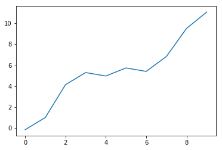

```python
import matplotlib.pyplot  as plt
%matplotlib inline
plt.plot(avg_scrores)
plt.show()
```

## Time to improvse the Model

There are 2 improvements 1) Adding priorities to Expirence replays..  
2) Adding more layers to neural network

In Expirence reply technique we used equal random policies.. No weights(probabilities) given to specific frame. But in this technique we use Prioritized expirence reply. Which mean we add probabilitied to each frame(state)..

We add more weight to frame we got more error. So it get trained better

But this needs bias correction. so we divide the number of samples x probablities raised to power of beta Also while adding probabilities we each state we will normalize it via (probabiliy /sum(probabluities)^ alpha We also need to add minimum probabilities to state so that it wonot be ignored

Adding more neural network layers reduces more bias

## Hyper parameter search

We need to check which paramters are doing better with model.. 1) lR 2) Epsolon decay

Learning rate is more importnant paramter which helps the neural network to understand at which pace it has to update weights EPS_decay is another parameter which tell when to stop taking random actions and when to start actions from model

```python
### lets do hypersearch for best paramenters for new model
from collections import deque
def hyper_search(env,  lrates, eps_decay, n_episodes=400):
    eps_end=0.01
    from DDQN_PE import Agent
    from collections import defaultdict
    scores = defaultdict(list)
    moving_scores = defaultdict(list)
    env_info = env.reset(train_mode=True)[brain_name]
    scores_window = deque(maxlen=100)
    state_size = env_info.vector_observations[0]
    action_size = brain.vector_action_space_size
    for lt in lrates:
        for i in eps_decay:
            eps=1.0
            eps_de = i
            score_string =  'my__' + str(lt)  + '__' + str(eps_de)
            agent = Agent(state_size=len(state_size), action_size=action_size, seed=0,learnrate=lt)
            print("starting {}".format(score_string))
            for i_episode in range(1, n_episodes + 1):
              env_info = env.reset(train_mode=True)[brain_name]
              state = env_info.vector_observations[0]  # get the current state
              score = 0
              while True:
                 action = agent.act(state, eps)
                 env_info = env.step(action)[brain_name]
                 next_state = env_info.vector_observations[0]  # get the next state
                 reward = env_info.rewards[0]  # get the reward
                 done = env_info.local_done[0]
                 agent.step(state, action, reward, next_state, done)
                 state = next_state
                 score += reward
                 if done:
                    break
              # save most recent score
              scores[score_string].append(score)  # save most recent score
              eps = max(eps_end, eps_de * eps)  # decrease epsilon
              scores_window.append(score)
              scores[score_string].append(score)
              print('\rEpisode {}\tAverage Score: {:.2f}'.format(i_episode, np.mean(scores_window)), end="")
              if i_episode % 100 == 0:
                 print('\rEpisode {}\tAverage Score: {:.2f}'.format(i_episode, np.mean(scores_window)))
                 moving_scores[score_string].append(np.mean(scores_window))

    return scores,moving_scores
```

```python
lrates = [1e-4, 2e-4, 5e-4]
eps_decay = [0.99,0.95,0.9]
eps_start=1.0
eps_end=0.01
```

```python
hyper_scores,hyper_moving_scores = hyper_search(env, lrates,eps_decay, n_episodes=400)
```

```
starting my__0.0001__0.99
Episode 100	Average Score: 1.61
Episode 200	Average Score: 5.94
Episode 300	Average Score: 8.69
Episode 400	Average Score: 13.08
starting my__0.0001__0.95
Episode 100	Average Score: 1.62
Episode 200	Average Score: 7.00
Episode 300	Average Score: 9.34
Episode 400	Average Score: 13.82
starting my__0.0001__0.9
Episode 100	Average Score: 1.34
Episode 200	Average Score: 6.13
Episode 300	Average Score: 9.27
Episode 400	Average Score: 12.08
starting my__0.0002__0.99
Episode 100	Average Score: 1.23
Episode 200	Average Score: 5.64
Episode 300	Average Score: 10.79
Episode 400	Average Score: 13.40
starting my__0.0002__0.95
Episode 100	Average Score: 2.55
Episode 200	Average Score: 8.56
Episode 300	Average Score: 11.48
Episode 400	Average Score: 13.04
starting my__0.0002__0.9
Episode 100	Average Score: 1.54
Episode 200	Average Score: 5.65
Episode 300	Average Score: 9.32
Episode 400	Average Score: 11.96
starting my__0.0005__0.99
Episode 100	Average Score: 1.28
Episode 200	Average Score: 7.30
Episode 300	Average Score: 11.44
Episode 400	Average Score: 13.56
starting my__0.0005__0.95
Episode 100	Average Score: 2.42
Episode 200	Average Score: 8.45
Episode 300	Average Score: 10.72
Episode 400	Average Score: 14.17
starting my__0.0005__0.9
Episode 100	Average Score: 3.38
Episode 200	Average Score: 9.58
Episode 300	Average Score: 12.78
Episode 400	Average Score: 15.05
```

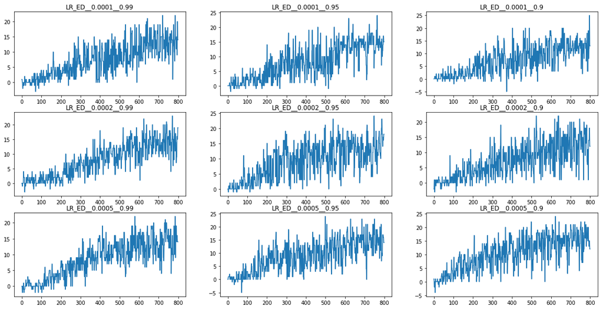

```python
## lets start with hyper paramter search

import matplotlib.pyplot as plt
%matplotlib inline

row=[1,2,3]
col=[1,2,3]
x_indx=1
y_indx=1
fig2 = plt.figure(figsize=(20,10))
for j in hyper_scores.keys():
    label = j.replace('my','LR_ED')
    ax = fig2.add_subplot(3,3,x_indx)
    #plt.subplot(9,x_indx,y_indx)
    ax.plot(hyper_scores[j])
    ax.set_title(label)
    x_indx += 1

plt.show()
```

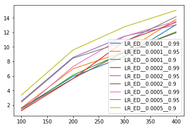

```python
x=[100,200,300,400]
for j in hyper_scores.keys():
    label = j.replace('my','LR_ED')
    plt.plot(x,hyper_moving_scores[j],label=label)
plt.legend(loc='lower right')
plt.show()
```

```python
for j in hyper_scores.keys():
    j_max = max(hyper_scores[j])
    j_min = min(hyper_scores[j])
    j_mean = sum(hyper_scores[j]) / len(hyper_scores[j])
    print("{} got max value {} and min_val of {} and avg of {}".format(j,j_max,j_min,j_mean))
```

```
my__0.0001__0.99 got max value 22.0 and min_val of -3.0 and avg of 7.33
my__0.0001__0.95 got max value 24.0 and min_val of -2.0 and avg of 7.945
my__0.0001__0.9 got max value 25.0 and min_val of -5.0 and avg of 7.205
my__0.0002__0.99 got max value 23.0 and min_val of -3.0 and avg of 7.765
my__0.0002__0.95 got max value 24.0 and min_val of -1.0 and avg of 8.9075
my__0.0002__0.9 got max value 22.0 and min_val of -3.0 and avg of 7.1175
my__0.0005__0.99 got max value 22.0 and min_val of -2.0 and avg of 8.395
my__0.0005__0.95 got max value 24.0 and min_val of -5.0 and avg of 8.94
my__0.0005__0.9 got max value 24.0 and min_val of -4.0 and avg of 10.1975
```